# Homework 3

Zehao Wang

2022-05-02

```r
library(tidyverse)
```

## 16.

Ignore the fpc,
$$V(\hat{y}_{str,
d})=\sum\left(\frac{N_h}{N}\right)^2\frac{S^2}{n_h}
=S^2\sum_{h=1}^H\left(\frac{N_h}{n_h}\right)\left(\frac{N_h}{N^2}\right).$$

And $w_{hj}=N_h/n_h$,
$$V(\hat{y}_{str,
d})=\left(\frac{S}{N}\right)^2\sum_{h=1}^H N_h w_h.$$

For proportional sample:
$$V(\hat{y}_{str,p})=\sum\left(\frac{N_h}{N}\right)^2\frac{S^2}{n_h}=\sum\left(\frac{N_h}{N}\right)^2\frac{S^2}{n\times
N_h/N}=\frac{S^2}{nN}\sum_{h=1}^HN_h=S^2/n.$$

Therefore,
$$\frac{V(\hat{y}_{str,d})}{V(\hat{y}_{str,p})}=\frac{n}{N^2}\sum_{h=1}^HN_hw_h=\frac{n}{N}\sum_{h=1}^H\frac{N_h}{N}w_h.$$

## 31. IPUMS exercise.

```r
data <- read_csv("ipums.csv")
```

### a), Use the file ipums.csv to select a two-stage stratified cluster sample from the population. Select two psus from each stratum, with probability proportional to size. Then take a simple random sample of persons from each selected psu; use the same subsampling size within each psu. Your final sample should have about 1200 persons.

```r
(
  prob_psu <- data %>%
    select(c(1, 2)) %>%
    group_by(stratum, psu) %>%
    summarise(n = n()) %>%
    ungroup() %>%
    group_by(stratum) %>%
    summarise(n, prob = n / sum(n))
)
```

| stratum | n | prob |
| --- | --- | --- |
| 1 | 904 | 0.08775847 |
| 1 | 1082 | 0.10503835 |
| 1 | 1286 | 0.12484225 |
| 1 | 1094 | 0.10620328 |
| 1 | 1077 | 0.10455296 |
| 1 | 1020 | 0.09901951 |
| 1 | 951 | 0.09232113 |
| 1 | 928 | 0.09008834 |
| 1 | 985 | 0.09562178 |
| 1 | 974 | 0.09455393 |

[output cut: 80 more lines]

So, first, we need to decide which psu should be selected out.

```r
selected_psu <- c()

for (i in 1:9) {
  a <- (i - 1) * 10 + 1
  b <- i * 10
  selected_psu <-
    append(selected_psu, sample((a:b), 2, prob = prob_psu$prob[a:b]))
}
```

Subsample from selected psu.

```r
get_subsample <- function(i) {
  now_data <- data %>%
    filter(psu == selected_psu[i])
  n <- now_data %>%
    count() %>%
    pull(n)
  select_sample <- sample(c(1:n), 67)
  now_data[select_sample, ]
}

final_sample <- get_subsample(1)
```

Obtain the sample:

```r
for (i in c(2:18)) {
  a_2 <- get_subsample(i)
  final_sample <- full_join(final_sample, a_2)
}
final_sample
```

| stratum | psu | inctot | age | sex | race | hispanic | marstat | ownershg | yrsusa | school | educrec | labforce | classwk | vetstat |
| --- | --- | --- | --- | --- | --- | --- | --- | --- | --- | --- | --- | --- | --- | --- |
| 1 | 9 | 2005 | 50 | 2 | 2 | 0 | 1 | 2 | 0 | 1 | 4 | 1 | 28 | 1 |
| 1 | 9 | 2005 | 19 | 2 | 2 | 0 | 1 | 1 | 0 | 1 | 7 | 2 | 22 | 1 |
| 1 | 9 | 4505 | 52 | 2 | 2 | 0 | 3 | 2 | 0 | 1 | 2 | 2 | 22 | 1 |
| 1 | 9 | 0 | 32 | 1 | 2 | 0 | 5 | 2 | 0 | 1 | 3 | 1 | 0 | 1 |
| 1 | 9 | 1565 | 44 | 2 | 2 | 0 | 4 | 1 | 0 | 1 | 8 | 2 | 22 | 1 |
| 1 | 9 | 22535 | 28 | 1 | 1 | 0 | 1 | 1 | 0 | 1 | 9 | 2 | 22 | 1 |
| 1 | 9 | 12360 | 47 | 1 | 1 | 0 | 1 | 1 | 0 | 1 | 7 | 2 | 22 | 2 |
| 1 | 9 | 23090 | 69 | 1 | 1 | 0 | 1 | 1 | 0 | 1 | 9 | 2 | 28 | 1 |
| 1 | 9 | 4505 | 39 | 2 | 1 | 0 | 1 | 1 | 0 | 1 | 7 | 2 | 28 | 1 |
| 1 | 9 | 26605 | 70 | 1 | 1 | 0 | 1 | 1 | 0 | 1 | 3 | 1 | 0 | 2 |

[output cut: 1196 more lines]

## b), Construct the column of sampling weights for your sample.

```r
(
  weight <- prob_psu %>%
    group_by(stratum) %>%
    summarise(
      prob_1 = prob,
      prob_2 = 67 / n,
      prob = prob_1 * prob_2 * 2,
      weight = 1 / prob
    ) %>%
    summarise(weight = max(weight))
)
```

| stratum | weight |
| --- | --- |
| 1 | 76.87313 |
| 2 | 27.82836 |
| 3 | 28.93284 |
| 4 | 41.62687 |
| 5 | 20.79851 |
| 6 | 41.46269 |
| 7 | 85.75373 |
| 8 | 34.31343 |
| 9 | 41.37313 |

## c), Draw a histogram of the variable inctot for your sample, using the weights.

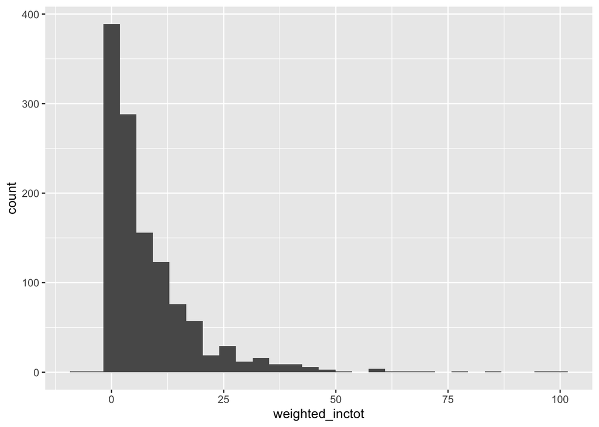

```r
final_sample %>%
  mutate(weighted_inctot = final_sample$inctot * rep(weight$weight, 1, each = 134) /
           sum(rep(weight$weight, 1, each = 134))) %>%
  ggplot() +
  geom_histogram(aes(weighted_inctot))
```

## d), Construct side-by-side box-plots of the variable inctot for each level of maritalstatus (variable marstat).

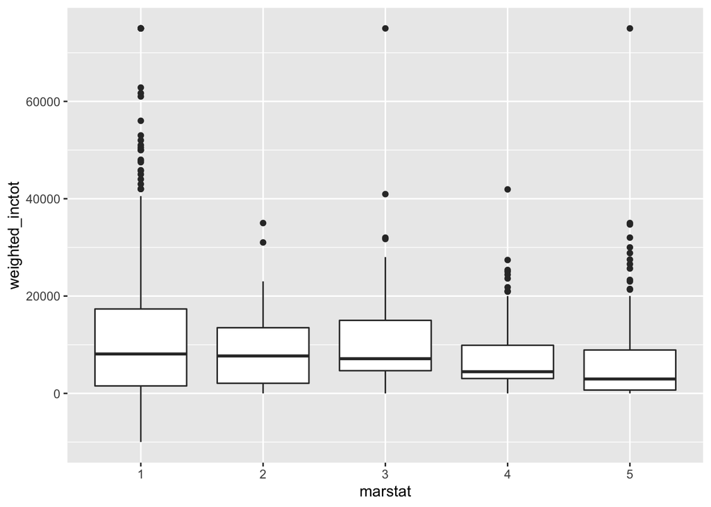

```r
final_sample["marstat"] <- factor(final_sample$marstat)

final_sample %>%
  mutate(weighted_inctot = final_sample$inctot) %>%
  ggplot(aes(x = marstat, y = weighted_inctot)) +
  geom_boxplot()
```

## e), Draw two of the scatter plots that incorporate weights, for y variable inctot and x variable age. How do these differ from scatterplots that do not use the weights?

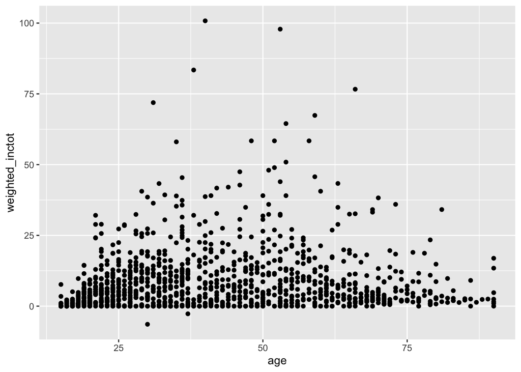

```r
final_sample %>%
  mutate(weighted_inctot = final_sample$inctot * rep(weight$weight, 1, each = 134)  /
           sum(rep(weight$weight, 1, each = 134))) %>%
  ggplot(aes(x = age, y = weighted_inctot)) +
  geom_point()
```

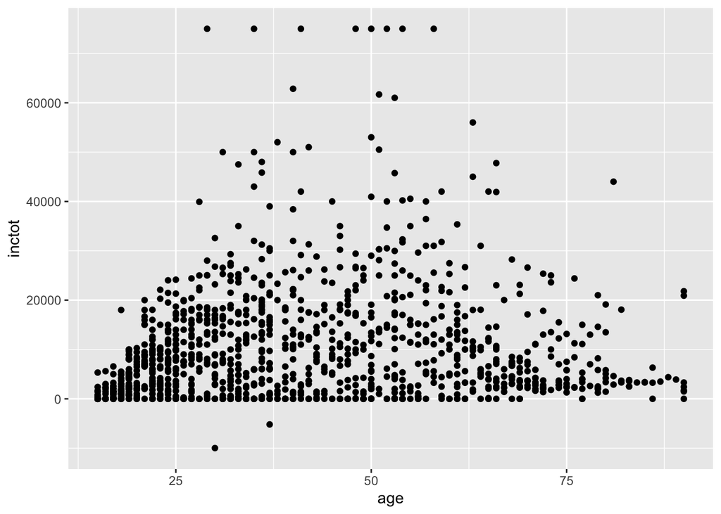

```r
final_sample %>%
  ggplot(aes(x = age, y = inctot)) +
  geom_point()
```

$$\hat{\bar{y}}=\frac{\sum w_i\cdot
y_i}{\sum w_i}.$$

```r
sum(final_sample$inctot * rep(weight$weight, 1, each = 134)) /
  sum(rep(weight$weight, 1, each = 134))
```

```
## [1] 9858.496
```

$$\hat{S}^2=\frac{N}{N-1}\left[\sum y^2
f(y)-\left(\sum y f(y)\right)^2\right].$$
$$SE(\hat{\bar{y}})=\sqrt{S^2}.$$

```r
(se_d <- sqrt(1206 / (1206 - 1) * (sum(
  final_sample$inctot ^ 2 * rep(weight$weight, 1, each = 134)
) /
  sum(rep(
    weight$weight, 1, each = 134
  )) -
  (
    sum(final_sample$inctot * rep(weight$weight, 1, each = 134)) /
      sum(rep(weight$weight, 1, each = 134))
  ) ^ 2)))
```

```
## [1] 11422.95
```

## g), Compare your results with those from an SRS with the same number of persons. Find the design effect of your response (the ratio of your variance from the unequal- probability sample to the variance from the SRS).

Calculate the variance of SRS.

```r
(se_p <- sqrt(1206 / (1206 - 1) * (
  sum(final_sample$inctot ^ 2 * 1206 / 53461) /
    (1206 * 1206 / 53461) -
    (sum(final_sample$inctot * 1206 / 53461) /
       ((1206 * 1206 / 53461))) ^ 2
)))
```

```
## [1] 11586.84
```

So, deff is

```r
se_d ^ 2 / se_p ^ 2
```

```
## [1] 0.971912
```